# Chapter 4 Supplementary Materials

# 1 Introduction

# 2 Introduction

# 3 Observed BMI Trends over time

This analysis will use data sources from the Australian Bureau of Statistics National Health Survey (2007/2008, 2011/2012, 2014/2015, 2017/2018), Longitudinal Study of Australia Children (2004-2016) and the 2007 National Children Nutrition and Physical Activity Survey to combine and summarise the prevalence of BMI categories across multiple age groups by gender.

## 3.1 Aims

The aims are to produce estimated trends of Obese, Overweight and Healthy weight over time accounting for known characteristics of the outcome, mainly; (1) the sum of the prevalence’s for each age and gender cohort is equal to one and that (2) each prevalence is a positive number between 0 and 1.

Combined and synthesised trend estimates will be used to assist the calibration of the system dynamics model by having a time-continuous set of prevalence data.

## 3.2 Method

Multinomial logistic regression will be used to ensure that the predicted outputs adhere to the above constraints. Fitted esimates of prevelance over time are inputed into the model for calibration. Observed data is used to confirm model’s replication of outcome’s behaviour.

### 3.2.1 Converting age groups

Published age groups often differed from those used in the system dynamic model. When individual ages are not presented in published data, a mean is taken to convert estimates from difference age groups. This assumed a uniform distribution of BMI within each age group.

For example, the system dynamic model (SDM) uses a 3 year age cohort for children, such as children aged 9-11 year olds (9-10, 10-11, 11-12). However, ABS data is published using 5 year groups of which two cover the modelling age groups, 5-9 years and 10-14 years. In this situation, 1/3 of the prevalence for 5-9 years olds and 2/3 of the prevalence of 10-14 years is combined to estimate the prevalence on 9-11 year olds.

Similarly, when an SDM age groups is encapsulated by a published age groups, the prevalence are assumed equal. For example, the SDM age group 6-8 year olds is encapsulated in the published data for 5-9 year olds. The prevalence of 6-8 year olds is assumed to be equal to 5-9 year olds.

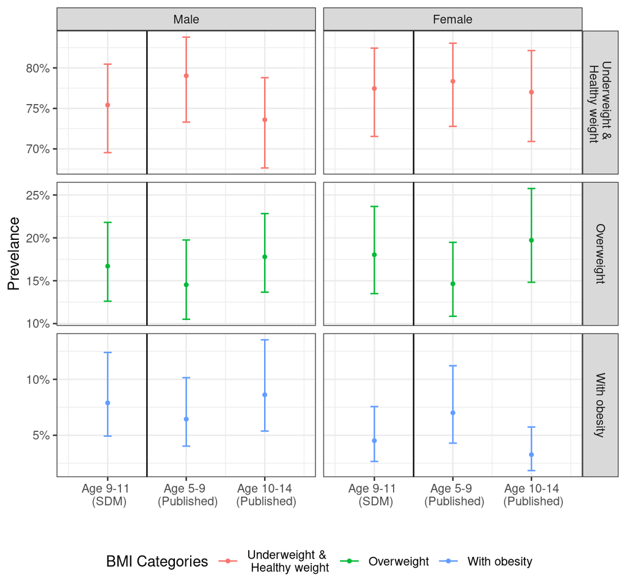

## 3.3 Results

### 3.3.1 Outcome by Data sources

[figure not shown]

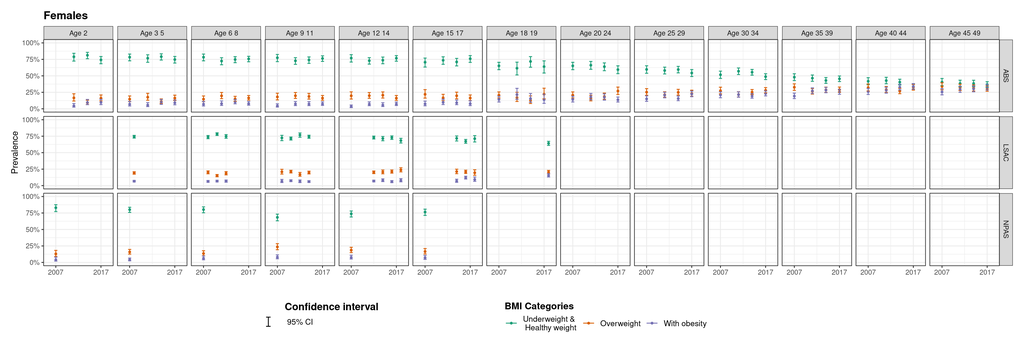

## 3.4 Outcome by BMI Category

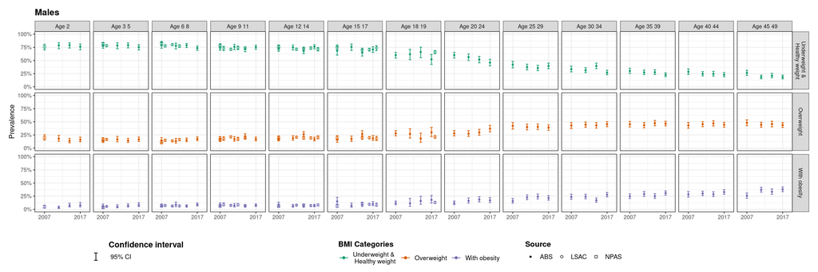

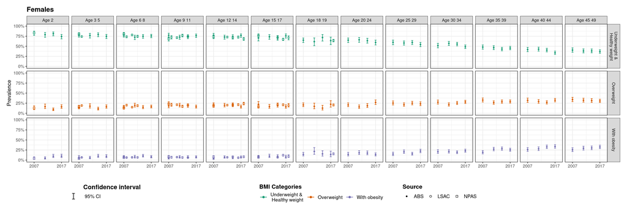

Here we manually estimate the loess predicted values for the data

Here we are estimating the calender projections of the observed data

Using all of the age groups, gender and year might meant the model was trying to average across too many data points, we took age and gender specific models (filter by age and gender then estimate the multinomial) and this seems to have better difference between genders.

## 3.5 Checking the predicted

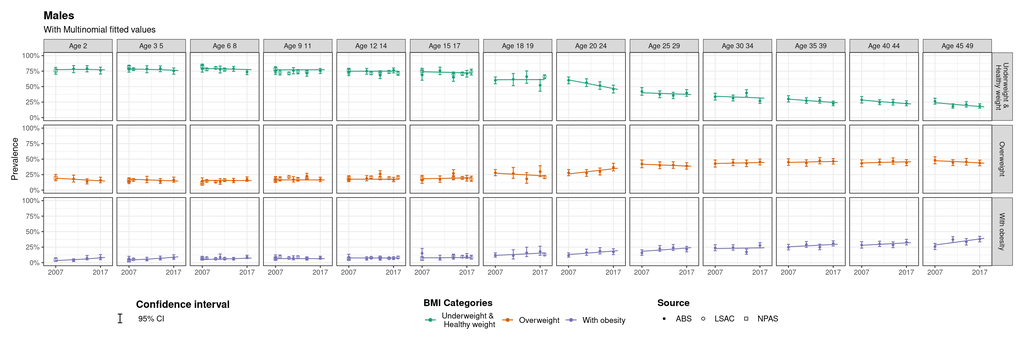

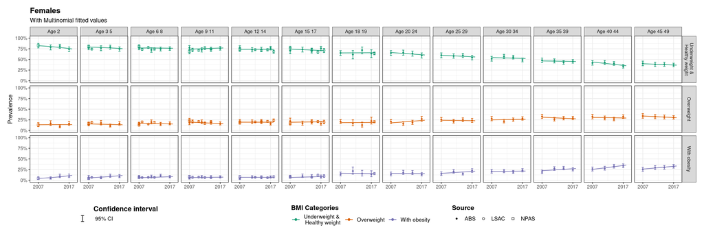

## 3.6 Transforming the data for Stella

[figure not shown]

```r
par(mar = c(4, 4, .1, .1))
plot(pressure, type = 'b', pch = 19)
```

[output not shown]

```r
knitr::kable(
  head(pressure, 10), caption = 'Here is a nice table!',
  booktabs = TRUE
)
```

[output not shown]

[output not shown]

# 4 NPAS

# 5 LSAC

# 6 EPOCH analysis

# 7 References